# 2.0.2. Preprocesing. Analisis de las variables.

Realizado por:

*Sergio Ranz Casado*  
*Marcos Medina Cogolludo*

Una vez realizado el EDA, y teniendo en cuenta el notebook 0.1. donde realizamos una primera exploración rapida de datos. Realizamos el preprocesamiento de datos. En este sentido estos son los puntos que trataremos:

## **2.0.1. Limpieza del dataset:**

1. Eliminación de los duplicados.
2. Eliminación de valores anómalos. (Vehiculos del 2015 que han tenido un accidente en el 2014).
3. Agrupación de los valores por accidente.

## **2.0.2. Analisis de las variables:**

1. Analisis de la distribución.
2. Analisis outliers variables continuas.
3. Correlacción variables continuas.
4. Eliminación de las variables correlaccionadas. Si procede.
5. Analisis variable objetivo.

## **2.0.3. SPLIT:**

1. División Train y Test.
2. Igualar la muestra de Train.
3. Tratamiento de variables numericas. Distribución continua.
4. Tratamiento de variables categoricas. Distribución discreta.

## **2.0.4. SELECCIÓN DE VARIABLES:**

1. Selección de variables.

#### Importo las librerias.

```python
import warnings
warnings.filterwarnings('ignore')
```

```python
import pandas as pd
import pyarrow.csv as pv
import pyarrow.parquet as pq
import seaborn as sns
import numpy as np
from matplotlib import pyplot as plt
from sklearn import preprocessing
import pandas as pd
import pyarrow.csv as pv
import pyarrow.parquet as pq
import seaborn as sns
```

#### Funciones a Utilizar:

```python
def plot_feature(df, col_name, target):
    """
    Visualize a variable with and without faceting on the loan status.
    - df dataframe
    - col_name is the variable name in the dataframe
    - full_name is the full variable name
    - continuous is True if the variable is continuous, False otherwise
    """
    f, (ax1, ax2) = plt.subplots(nrows=1, ncols=2, figsize=(18,5), dpi=90)

    df_n = df.groupby([target, col_name]).size().reset_index()
    df_n = df_n.rename(columns={0:"conteo"})
    df_n["porcentajes"] = df_n['conteo'] / df_n.groupby(target)['conteo'].transform('sum') * 100

    sns.countplot(df[col_name], order=sorted(df[col_name].unique()), color='#5975A4', saturation=1, ax=ax1)
    ax1.set_xlabel(col_name)
    ax1.set_ylabel('Count')
    plt.xticks(rotation = 90)


    sns.barplot(data=df_n, y="porcentajes", x=col_name, hue=target, ax=ax2)
    ax2.set_xlabel(col_name)
    ax2.set_ylabel('Distribución')
    plt.xticks(rotation = 90)
    plt.tight_layout()

def get_deviation_of_mean_perc(df_acc, list_var_continuous, target, multiplier):
    """
    Devuelve el porcentaje de valores que exceden del intervalo de confianza
    :type series:
    :param multiplier:
    :return:
    """
    pd_final = pd.DataFrame()

    for i in list_var_continuous:

        series_mean = df_acc[i].mean()
        series_std = df_acc[i].std()
        std_amp = multiplier * series_std
        left = series_mean - std_amp
        right = series_mean + std_amp
        size_s = df_acc[i].size

        perc_goods = df_acc[i][(df_acc[i] >= left) & (df_acc[i] <= right)].size/size_s
        perc_excess = df_acc[i][(df_acc[i] < left) | (df_acc[i] > right)].size/size_s

        if perc_excess>0:
            pd_concat_percent = pd.DataFrame(df_acc[target][(df_acc[i] < left) | (df_acc[i] > right)]\
                                            .value_counts(normalize=True).reset_index()).T
            pd_concat_percent.columns = [pd_concat_percent.iloc[0,0],
                                         pd_concat_percent.iloc[0,1]]
            pd_concat_percent = pd_concat_percent.drop('index',axis=0)
            pd_concat_percent['variable'] = i
            pd_concat_percent['sum_outlier_values'] = df_acc[i][(df_acc[i] < left) | (df_acc[i] > right)].size
            pd_concat_percent['porcentaje_sum_null_values'] = perc_excess
            pd_final = pd.concat([pd_final, pd_concat_percent], axis=0).reset_index(drop=True)

    if pd_final.empty:
        print('No existen variables con valores nulos')

    return pd_final
```

#### Importo el dataset guardado del preprocesing 2.0.1.

```python
df_acc = pd.read_parquet('../data/df_acc_1.parquet')
df_acc.columns = df_acc.columns.map(lambda x: x[:].lower())
df_acc
```

|  | c_year | c_mnth | c_wday | c_hour | c_sev | c_vehs | c_conf | c_rcfg | c_wthr | c_rsur | c_raln | c_traf | c_nums |
| --- | --- | --- | --- | --- | --- | --- | --- | --- | --- | --- | --- | --- | --- |
| 0 | 1999 | 01 | 1 | 00 | 2 | 01 | 01 | 01 | 1 | 4 | 1 | 18 | 1 |
| 1 | 1999 | 01 | 1 | 00 | 2 | 01 | 01 | 01 | 1 | 5 | 1 | 18 | 1 |
| 2 | 1999 | 01 | 1 | 00 | 2 | 01 | 01 | 01 | 2 | 1 | 1 | 18 | 1 |
| 3 | 1999 | 01 | 1 | 00 | 2 | 01 | 01 | 01 | 6 | 3 | 2 | 18 | 2 |
| 4 | 1999 | 01 | 1 | 00 | 2 | 01 | 01 | UU | 1 | 2 | 3 | 18 | 1 |
| ... | ... | ... | ... | ... | ... | ... | ... | ... | ... | ... | ... | ... | ... |
| 1850312 | 2014 | 12 | 7 | UU | 2 | 02 | UU | 02 | U | U | 1 | 03 | 2 |
| 1850313 | 2014 | UU | U | 14 | 2 | 01 | 02 | 01 | 1 | 5 | 4 | 18 | 1 |
| 1850314 | 2014 | UU | U | 22 | 1 | 01 | 06 | 01 | 2 | 4 | Q | 18 | 2 |
| 1850315 | 2014 | UU | U | 23 | 2 | 01 | 06 | 05 | 1 | 1 | U | 18 | 1 |
| 1850316 | 2014 | UU | U | UU | 2 | UU | UU | 01 | U | U | U | UU | 20 |

1850317 rows × 13 columns

#### Variables.

Dentro del dataset, vamos a diferenciar las variables numericas continuas, de las categoricas discretas.

```python
variables_continuas = df_acc[["c_year","c_vehs","c_nums"]].columns
variables_discretas = df_acc.drop(variables_continuas, axis=1).columns
```

#### Análisis de las distribuciones de las variables del dataset.

#### Vemos las distribuciones de las variables discretas:

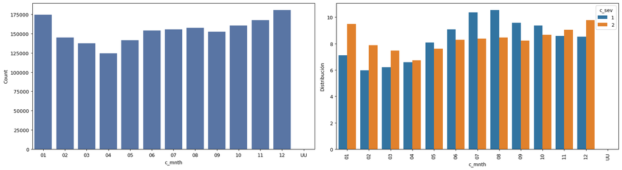

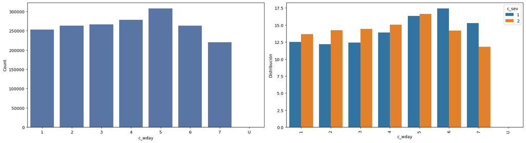

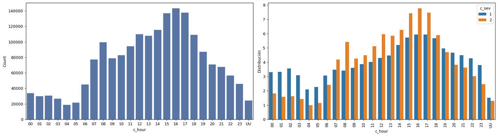

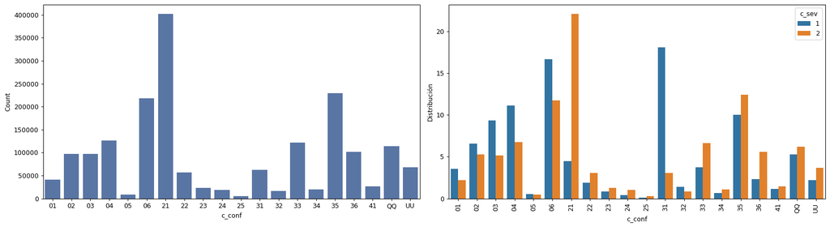

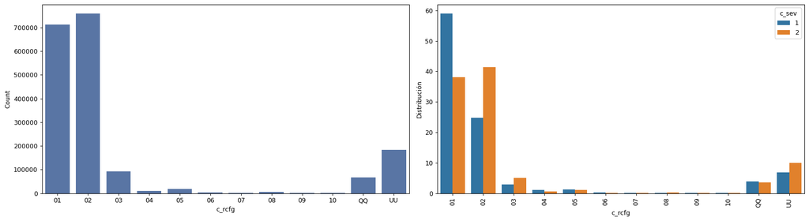

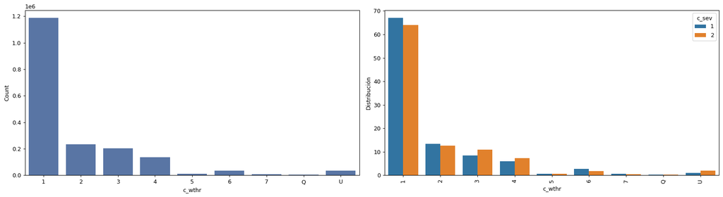

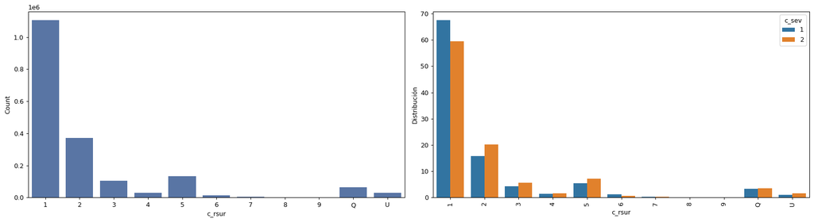

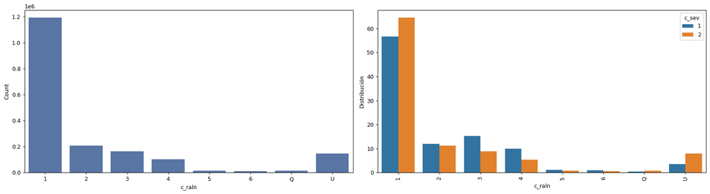

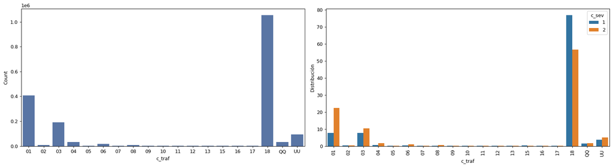

```python
for i in variables_discretas:
    if i != "c_sev":
        plot_feature(df_acc,i,"c_sev")
```

#### Distribuciones de las variables continuas.

solo tenemos 3 variables continuas seleccionadas, primero realizamos un describe en el que sabremos mas de las variables, posteriormente las analizamos las tres variables por separado, ya que no nos supondrá mucho tiempo...

```python
df_acc[variables_continuas].describe().apply(lambda s: s.apply(lambda x: format(x, 'g')))
```

|  | c_year | c_nums |
| --- | --- | --- |
| count | 1.85032e+06 | 1.85032e+06 |
| mean | 2006.11 | 3.1638 |
| std | 4.56176 | 2.63415 |
| min | 1999 | 1 |
| 25% | 2002 | 2 |
| 50% | 2006 | 2 |
| 75% | 2010 | 4 |
| max | 2014 | 123 |

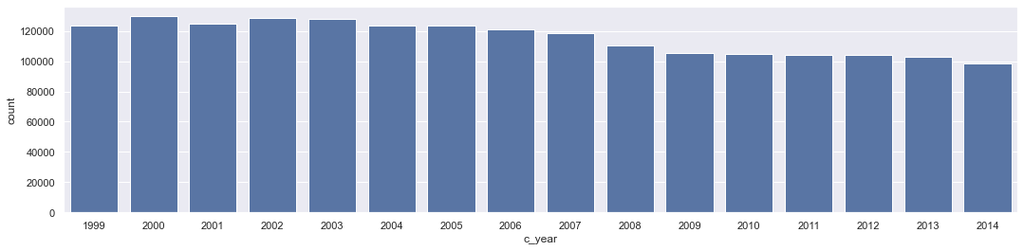

```python
sns.set(rc={'figure.figsize':(18, 4)})
sns.countplot(df_acc["c_year"], order=sorted(df_acc["c_year"].unique()), color='#5975A4', saturation=1)
```

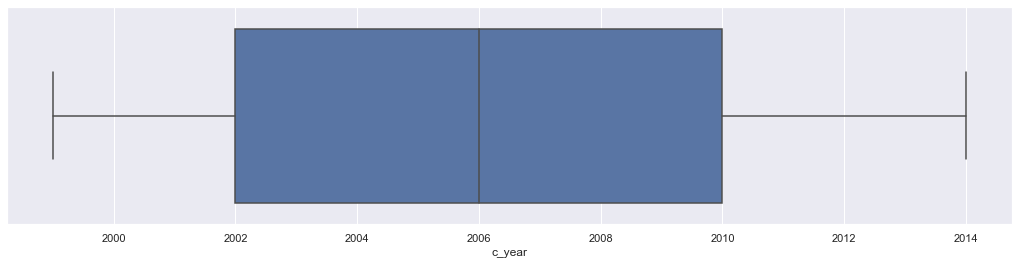

```python
sns.boxplot(df_acc["c_year"])
```

**c_nums:** Hemos encontrado bastantes valores anomalos con respecto al numero de personas que han participado en un accidente de trafico. La distribución esta muy desequilibrada. En este caso los valores extremos no representan un aumento en la tasa de mortalidad, **por lo que no habra problemas si los eliminamos**

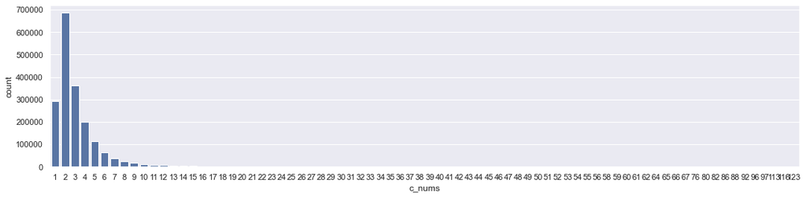

```python
sns.set(rc={'figure.figsize':(18, 4)})
sns.countplot(df_acc["c_nums"], order=sorted(df_acc["c_nums"].unique()), color='#5975A4', saturation=1)
```

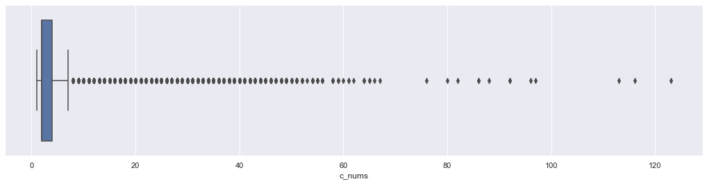

```python
sns.set(rc={'figure.figsize':(18, 4)})
sns.boxplot(df_acc["c_nums"])
```

**C_vehs:** Es el numero de vehiculos colisionados en un accidente de trafico puedes estar muy relaccionado con la mortalidad. Primero cambiamos los valores NA y '' por un valor extremo , en este caso 99.

```python
df_acc.c_vehs = df_acc.c_vehs.replace("UU",99)
df_acc.c_vehs = df_acc.c_vehs.replace("",99)
df_acc.c_vehs = pd.to_numeric(df_acc.c_vehs)
```

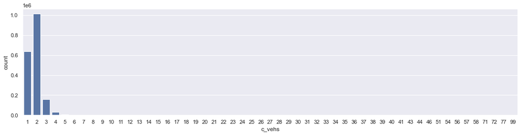

```python
sns.set(rc={'figure.figsize':(18, 4)})
sns.countplot(df_acc["c_vehs"], order=sorted(df_acc["c_vehs"].unique()), color='#5975A4', saturation=1)
```

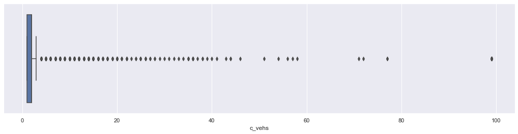

```python
sns.set(rc={'figure.figsize':(18, 4)})
sns.boxplot(df_acc["c_vehs"])
```

#### Vemos los outliers de las variables continuas....

```python
get_deviation_of_mean_perc(df_acc, variables_continuas, target='c_sev', multiplier=3)
```

|  | 2.0 | 1.0 | variable | sum_outlier_values | porcentaje_sum_null_values |
| --- | --- | --- | --- | --- | --- |
| 0 | 0.961996 | 0.038004 | c_vehs | 3447 | 0.001863 |
| 1 | 0.995026 | 0.004974 | c_nums | 31365 | 0.016951 |

`c_vehs`: Los outliers de c_vehs suponen un aumento del ratio de mortalidad de 1,9% hasta el 3.8%. NOs deberiamos de quedar con la información que contienen esas 3447 lineas y buscar la forma de atacar a la distribución de la variables(una distribución Poisson con muchos valores anomalos).

`c_nums`: Observamos como no supone un gran incremento los outliers en la tasa de mortalidad, al contrario, disminuye de 1,98% hasta un 0,5%. Buscaremos la manera de atacar la distribución de c_nums tambien.

#### Correlacción de las variables continuas:

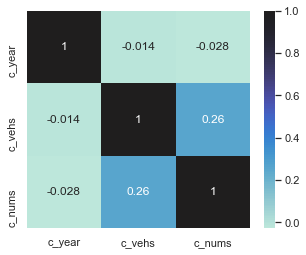

```python
sns.set(rc={'figure.figsize':(5, 4)})
sns.heatmap(df_acc[["c_year", "c_vehs", "c_nums"]].corr(), annot=True,center=1)
```

No existen correlacciones significativas entre las variables del dataset.

#### Análisis variable Objetivo `c_sev`

Volvemos a analizar la proporción de **muertes:1** y **no muertes: 2** tal y como hemos realizamos en el notebook **01.Load Data.** Queremos ver si la distribución continua de la misma manera una vez hemos agrupado el dataset.

```
Accidentes de trafico sin mortalidad: 1814477 ,Porcentaje %: 98.06
Accidentes de trafico con mortalidad: 35840 ,Porcentaje %: 1.94
```

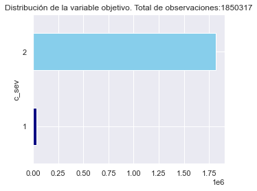

```python
df_csev = df_acc.groupby("c_sev").size()
df_csev.plot(kind="barh", color=["navy", "skyblue"],
             title="Distribución de la variable objetivo. Total de observaciones:"+str(df_acc.shape[0]))
print("Accidentes de trafico sin mortalidad:", df_csev[2], ",Porcentaje %:", (round(df_csev[2]/(df_csev[1]+df_csev[2])*100,2)))
print("Accidentes de trafico con mortalidad:", df_csev[1], ",Porcentaje %:", (round(df_csev[1]/(df_csev[1]+df_csev[2])*100,2)))
```

Vemos como la propoción no ha cambiado nada, por lo que tendremos que hacer algo para equilibrar el dataset.

#### Conclusiones antes del Split:

1. Los valores NA del dataset nos pueden aportar mucho valor a la hora de predecir la variable objetivo `c_sev`. En función de cada variable haremos un tratamiento distinto. En principio pensamos decantarnos por dos codificaciones. La codificación, label encoder, para aquellas variables cuya distribución sea uniforme y weight encoder para aquellas cuya distribución no sea equitativa.
2. Las variables continuas `c_vehs` y `c_nums` tienen bastantes outliers, aunque solo los valors `c_vehs` influyen en una mayor proporción en la mortalidad. En ambas escalas realizamos un robust scaler, ya que nuestra prioridad es atacar al gran numero de outliers que ambos tienen.
3. No existen correlacciones altas entre las variables continuas.